# COMM 3710: Survey Research

# Survey Research

🤔 Let’s begin by examining some examples of survey questions. As you read these, think about why a respondent might be hesitant to provide an answer to each question. Write down your these thoughts so you can compare your notes with mine.

While you can easily find fault with the response options provided for each survey question, try to focus instead on the wording of the question itself or the way the question is asked.

1. Suppose you were in a bookstore and saw a book which you wanted very much but could not afford, displayed on a counter near the door. Would you steal it?
   - Yes
   - No
2. Many people these days have come to see marijuana as being far less harmful than tobacco or alcohol and they urge that its use be made legal. Do you agree or disagree with those people?
   - Agree
   - Disagree
   - Don’t know
3. How much money do you make? $___________________
4. Did you watch the Democratic and Republican National Conventions?
   - Yes
   - No

If YES, how much attention did you pay to them?

- Close attention
- Some attention
- Little attention
5. Where do you get most of your information about current events in the nation and the world?
   - Radio
   - Newspapers
   - Magazines

> Check your answers [here](https://utah.instructure.com/files/131421318/download?download_frd=1).

# What is a Survey?

A **survey** is a social scientific method for gathering quantifiable information about a specific group of people by asking the group members questions about their individual attitudes, values, beliefs, behaviors, knowledge, and perceptions.

A **questionnaire** is a form containing a series of questions and mental measures given to a group of people in an attempt to gain statistical information about the group as part of a survey.

There are different types of surveys. Two that we will define in this course are:

1. **Cross-sectional survey**: A survey that is conducted at a single time point.
2. **Longitudinal survey**: A survey that is conducted at multiple time points. The respondents surveyed at these time points can be the same people (panel survey) or different people (trend survey).

## Opinion Polling

Polling is survey research that we often hear about in media, especially as it related to politics and public affairs. For example, the [Pew Research Center](https://www.pewresearch.org/) conducts polls on a variety of political and public affairs in the United States.

That said, people had some questions about the accuracy of polling following the 2016 election. Read the three articles below. Each highlights some of the contemporary challenges faced by polling.

- [Bialik and Enten (2016)](https://utah.instructure.com/files/131421352/download?download_frd=1)
- [Zukin (2015)](https://utah.instructure.com/files/131421341/download?download_frd=1)
- [Silver (2014)](https://utah.instructure.com/files/131421335/download?download_frd=1)

# When to Use Surveys

According to Buckingham and Saunders (2004)[^1], for researchers to decide whether a survey is the appropriate method, they should answer four questions:

1. Do you know what you want to ask?
2. Do you need to collect primary data?
3. Do your participants know anything? Will they tell you?
4. Is your goal generalizability?

Read about these four considerations in **Chapter 9 of your [textbook](https://utah.instructure.com/courses/800682/external_tools/73308?display=borderless)**.

# How to Conduct Survey Research

❓ At first glance, conducting a survey might seem easy. This is **far** from the truth. In fact, conducting a survey research project takes a significant amount of time and a lot of careful planning, testing, and revising.

As it states in your textbook, “[b]eing haphazard in one’s approach is not science” (Chapter 9). As with any research project, you should…

- start with an overarching research question or goal and…
- use it as a guide to designing a good survey project.

As a guide, Fink (2006)[^2] suggests five steps for conducting a survey. Although the sections below offer a summary of each step, be sure to read your textbook for detailed information.

## Step 1: Pick Your Questions

There is no single way to decide which questions you will need to ask on a survey. **The questions that you ask will be dictated by your hypotheses and specific research questions, which are driven by your overarching research question or goal**.

Read more about this in Wrench Ch. 9 and in the questionnaire construction section below.

## Step 2: Creating Clear Instructions

There is often ambiguity in a survey question that researchers fail to catch. While there are examples of clear instructions in a questionnaire in your textbook, I have also included an example from a mistake I made just a few years ago.

I was pilot testing a survey on a group of college students and asked them the following question:

[figure not shown]

The drop-down list of response choices ranged from `0` to `31 or more`. The frequency distribution of the responses is shown below. This type of graph shows the response categories on the x-axis (horizontal) and the number of responses for each category, or the frequency of each category, on the y-axis (vertical).

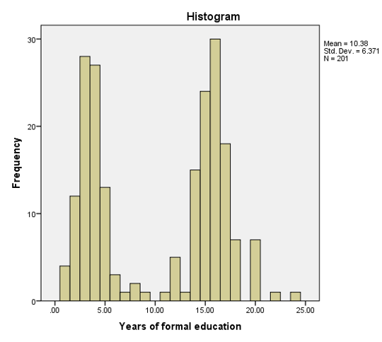

Since my sample consisted only of college students, I expected responses to only be in categories > 12 years of formal education. However, my question was poorly worded. It looks like some respondents thought that the question was asking them about how many years of **college** education they had completed. 😱

As a result of this pilot test, I revised this survey question as follows. As you can see, the question contains a more specific definition of “formal education.”

[figure not shown]

## Step 3: Study Design

As a researcher, you must decide whether a *cross-sectional* or *longitudinal* survey will be a better design for addressing your hypotheses and research questions.

Review the definitions of cross-sectional and longitudinal surveys in your textbook or in the section, What is a Survey?

## Step 4: Data Processing and Analysis

The short explanation of this step: Researchers must have a plan for data processing and analysis when they design their survey.

To do so, you must have some idea of how survey responses are used in statistical analysis, a topic that we will get to later in the semester. Additionally, your assignments with R are designed to give you hands-on experience with data management, processing, and analysis.

## Step 5: Pilot Testing

✈️ A **pilot test** is a small-scale test-run of your survey project. As illustrated in Step 2, this can often bring to light issues with the questionnaire or study design that the researchers did not anticipate.

It is critical to pilot test your questionnaire before conducting the full study. Your textbook describes a relatively in-depth pilot study. Not all researchers need or are able to conduct such a comprehensive pilot study for all projects. There are degrees of comprehensiveness of pilot studies. For example, a researcher might pilot test some questions on a survey about which they are unsure instead of the entire survey.

These types of decisions are among the many that researchers make when conducting a study. Often, there are no correct or incorrect answers. Instead, **decisions should be made with an eye toward addressing the hypotheses and research questions that drive a study**.

# Questionnaire Construction

📏 We use a questionnaire because it is a **standardized measurement instrument** that allows us to collect **valid** and **reliable** data.

Although we call it a questionnaire, not all of the “questions” contained within it are true questions. Many questions are in the form of statements that require participants to indicate the degree to which they agree or disagree with the statements.

The agree-disagree scales that many of us are familiar with are known as Likert scales (see example in [Week 1](https://sarakyeo.github.io/COMM-3710/week1.html); search the page for “Likert”) and they are interval level measures (if this term is unfamiliar, review levels of measurement in [Week 4](https://sarakyeo.github.io/COMM-3710/week4.html#Measurement)).

Two important aspects of questionnaire construction that researchers must pay attention to when creating a survey are:

1. Overall structure of the questionnaire
2. Specific question wording

Being mindful of these aspects increases the likelihood that respondents will complete a survey. The video below discusses both these aspects in more detail.

[video not shown]

# Strengths and Weaknesses of Survey Research

> **Survey research is generally strong on reliability but *can* be weak on validity**.

## Strengths 💪

1. Surveys allow researchers to make inferences to large groups of people. In other words, surveys allow us to make **generalizations**. Of course, this means that we must first have valid and reliable measures of the concepts of interest in your survey and we must employ probability sampling techniques to obtain a representative sample of the population.
2. We can often have **large samples** in a survey. It is not uncommon to have sample sizes upwards of 2,000 respondents. If we use probability sampling techniques, this allows us to make more accurate predictions and inferences about the population of interest.

## Weaknesses/Challenges 🤷

1. Sometimes, conducting survey research can be like trying to fit round pegs into square holes. Because we have standardized questionnaires for every respondent, we might miss some complexities and nuances in people’s attitudes, opinions, behaviors, perceptions, etc. However, this can often be overcome through a combination of careful concept explication prior to data collection and sophisticated statistical analyses after data collection.
2. Another critique of survey research is its **artificiality**. We cannot always use surveys to answer all our research questions. Additionally, if we have a sensitive topic, we may influence respondents’ answers by asking survey questions about it. **Artificiality strains the validity of our surveys**; if the situation in which respondents are answering our survey suffers from the problem of artificiality, we may not be able to tell whether the results obtained are accurate reflections of our respondents’ views.
3. A **response rate** is the proportion of surveys completed relative to the number of surveys distributed. For example, if you hand out 1,000 surveys and 950 are returned, your response rate is 95%. This high of a response rate is rare. In the real world, response rates are commonly below 50%. In fact, they are more likely to range between 15% and 35%, depending on the type and length of survey, as well as they type of sample. **It is important for survey researchers to consider response rates when designing surveys**. Read about the different types of nonresponse, **unit nonresponse** and **item nonresponse**, in your textbook (Chapter 9).

# Secondary Analysis

Survey research projects are major undertakings. It can take a year or more to progress from concept explication to data collection. Often, researchers will obtain data that have been collected by other researchers and **re-analyze** them to **address different questions and hypotheses**.

This is known as **secondary analysis** and the data used for such analyses are known as **secondary data**. The data used in your individual assignments are secondary data.

## Advantages of Secondary Analysis 👍

- cheaper
- quicker
- allows researchers to conduct [meta-analyses](https://en.wikipedia.org/wiki/Meta-analysis)

## Disadvantages of Secondary Analysis 👎

- may be weak on validity
- data many not exactly fit or be appropriate to the research question
- measures may not be valid or reliable

# Common Sources of Secondary Data

The data sets listed below are some examples of sources of secondary data. Spend some time on each website and explore the data that can be downloaded. Many research questions have been answered using these secondary data.

- [Add Health: The National Longitudinal Study of Adolescents to Adult Health](https://addhealth.cpc.unc.edu)
- [Cooperative Election Study](https://cces.gov.harvard.edu)
- [General Social Survey (GSS)](https://gss.norc.org)
- [Health Information National Trends Survey (HINTS)](https://hints.cancer.gov)

## Examples of Published Research Using Secondary Data

Webster, S. W., & Abramowitz, A. I. (2017). The ideological foundations of affective polarization in the U.S. electorate. *American Politics Research*, 45(4), 621–647. https://doi.org/10.1177/1532673X17703132

Zhao, X. Q. (2009). Media use and global warming perceptions: A snapshot of the reinforcing spirals. *Communication Research*, 36(5), 698–723. https://doi.org/10.1177/0093650209338911

Besley, J. C. (2016). The National Science Foundation’s science and technology survey and support for science funding, 2006–2014. *Public Understanding of Science*, 0963662516649803. https://doi.org/10.1177/0963662516649803

Tsfati, Y., & Ariely, G. (2014). Individual and contextual correlates of trust in media across 44 countries. *Communication Research*, 41(6), 760–782. https://doi.org/10.1177/0093650213485972

Easterlin, R. A., McVey, L. A., Switek, M., Sawangfa, O., & Zweig, J. S. (2010). The happiness–income paradox revisited. *Proceedings of the National Academy of Science*s, 201015962. https://doi.org/10.1073/pnas.1015962107

[^1]: Buckingham, A., & Saunders, P. (2004). *The Survey Methods Workbook: From Design to Analysis* (1st ed.). Cambridge, UK: Polity Press.
[^2]: Fink, A. (2006). *How to conduct surveys: A step-by-step guide* (3rd ed.). Thousand Oaks, CA: Sage.